# Answers for the R Practice Assignments

```r
# now we can rejoin the slightly askew data
df.scatter <- merge(x = df.2019,
                    y = df.2020,
                    by.x = 'DayOfYear',
                    by.y = 'alignedDayOfYear',
                    all = TRUE, # keep all values, even if data is missing
                    suffixes = c(".2019", ".2020"))

head(df.scatter[,c("DayOfYear", "DayOfWeek.2019", "DayOfWeek.2020",
                   "Date.2019", "Date.2020", "DailyCounts.2019", "DailyCounts.2020")])
```

```
##   DayOfYear DayOfWeek.2019 DayOfWeek.2020  Date.2019  Date.2020
## 1         2      Wednesday           <NA> 2019-01-02       <NA>
## 2         3       Thursday       Thursday 2019-01-03 2020-01-02
## 3         4         Friday         Friday 2019-01-04 2020-01-03
## 4         5       Saturday       Saturday 2019-01-05 2020-01-04
## 5         6         Sunday         Sunday 2019-01-06 2020-01-05
## 6         7         Monday         Monday 2019-01-07 2020-01-06
##   DailyCounts.2019 DailyCounts.2020
## 1              323               NA
## 2              295              318
## 3              211              208
## 4              302              322
## 5              209              197
## 6              242              226
```

```r
# days of week match (Thursday 2019 to Thursday 2020)
# date is off by 1

# cleanup NAs - a few sorts
# drop first line of table because the NA there is uninformative
df.scatter <- df.scatter[2:length(df.scatter$DayOfYear),]

# likely need to drop last line too
tail(df.scatter)
```

```
##     DayOfYear  Date.2019 DayOfWeek.2019 Year.2019 DailyCounts.2019  Date.2020
## 355       362 2019-12-28       Saturday      2019              208 2020-12-26
## 356       363 2019-12-29         Sunday      2019              156 2020-12-27
## 357       364 2019-12-30         Monday      2019              248 2020-12-28
## 358       365 2019-12-31        Tuesday      2019              221 2020-12-29
## 359       366       <NA>           <NA>        NA               NA 2020-12-30
## 360       367       <NA>           <NA>        NA               NA 2020-12-31
##     DayOfWeek.2020 Year.2020 DailyCounts.2020 DayOfYear.2020
## 355       Saturday      2020               79            361
## 356         Sunday      2020               62            362
## 357         Monday      2020               16            363
## 358        Tuesday      2020              107            364
## 359      Wednesday      2020               91            365
## 360       Thursday      2020               65            366
```

```r
# let's drop last two days
df.scatter <- df.scatter[1:(length(df.scatter$DailyCounts.2019) - 2), ]

# let's inspect
head(df.scatter)
```

```
##   DayOfYear  Date.2019 DayOfWeek.2019 Year.2019 DailyCounts.2019  Date.2020
## 2         3 2019-01-03       Thursday      2019              295 2020-01-02
## 3         4 2019-01-04         Friday      2019              211 2020-01-03
## 4         5 2019-01-05       Saturday      2019              302 2020-01-04
## 5         6 2019-01-06         Sunday      2019              209 2020-01-05
## 6         7 2019-01-07         Monday      2019              242 2020-01-06
## 7         8 2019-01-08        Tuesday      2019              214 2020-01-07
##   DayOfWeek.2020 Year.2020 DailyCounts.2020 DayOfYear.2020
## 2       Thursday      2020              318              2
## 3         Friday      2020              208              3
## 4       Saturday      2020              322              4
## 5         Sunday      2020              197              5
## 6         Monday      2020              226              6
## 7        Tuesday      2020              255              7
```

```r
tail(df.scatter)
```

```
##     DayOfYear  Date.2019 DayOfWeek.2019 Year.2019 DailyCounts.2019  Date.2020
## 353       360 2019-12-26       Thursday      2019              223       <NA>
## 354       361 2019-12-27         Friday      2019              171       <NA>
## 355       362 2019-12-28       Saturday      2019              208 2020-12-26
## 356       363 2019-12-29         Sunday      2019              156 2020-12-27
## 357       364 2019-12-30         Monday      2019              248 2020-12-28
## 358       365 2019-12-31        Tuesday      2019              221 2020-12-29
##     DayOfWeek.2020 Year.2020 DailyCounts.2020 DayOfYear.2020
## 353           <NA>        NA               NA             NA
## 354           <NA>        NA               NA             NA
## 355       Saturday      2020               79            361
## 356         Sunday      2020               62            362
## 357         Monday      2020               16            363
## 358        Tuesday      2020              107            364
```

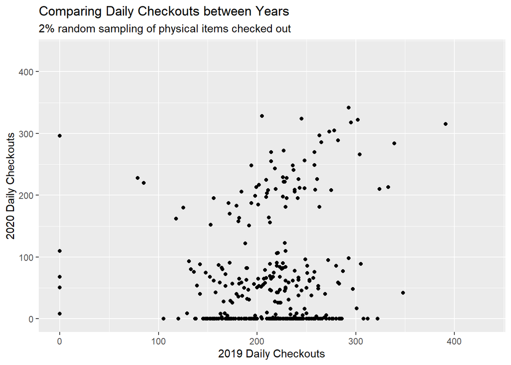

```r
# remaining NAs in counts can be switched to zeros (no checkouts those days, or very very few)
df.scatter$DailyCounts.2019[is.na(df.scatter$DailyCounts.2019)] <- 0
df.scatter$DailyCounts.2020[is.na(df.scatter$DailyCounts.2020)] <- 0

# get max value for limits
max.plus <- max(df.scatter$DailyCounts.2019, df.scatter$DailyCounts.2020) * 1.1 # to add some buffer

# now our count data is aligned and cleaned up, let's make a scatter plot!
(ggplot(df.scatter)
  + aes(x = DailyCounts.2019, y = DailyCounts.2020)
  + geom_point()

  # force limits to make a square (best for scatterplots)
  + scale_x_continuous("2019 Daily Checkouts", limits = c(0, max.plus))
  + scale_y_continuous("2020 Daily Checkouts", limits = c(0, max.plus))

  # titles
  + ggtitle("Comparing Daily Checkouts between Years",
            subtitle = "2% random sampling of physical items checked out")
  )
```

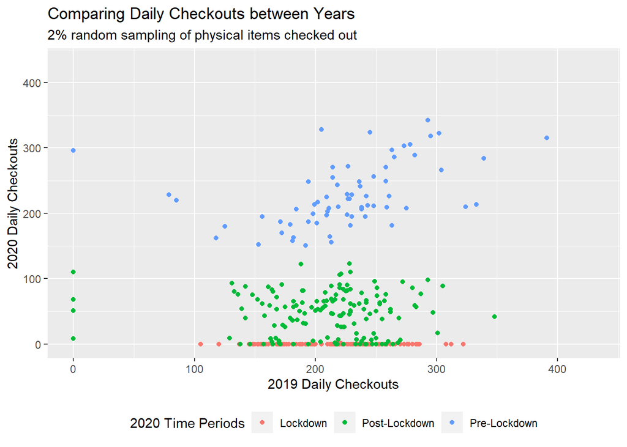

```r
# let's add some color groupings to learn more
# based on what we saw already, we might divide 2020 into three categories
#   Pre-lockdown - 1/1 - 3/14 (day 73)
#   Lockdown - 3/15 - 7/31 (day 212)
#   Post-lockdown - 8/1 - 12/31

df.scatter$pandemicGroup <- NA
df.scatter$pandemicGroup[df.scatter$DayOfYear > 212] <- "Post-Lockdown"
df.scatter$pandemicGroup[df.scatter$DayOfYear <= 212] <- "Lockdown"
df.scatter$pandemicGroup[df.scatter$DayOfYear <= 73] <- "Pre-Lockdown"

(ggplot(df.scatter)
  + aes(x = DailyCounts.2019, y = DailyCounts.2020,
        color = pandemicGroup)
  + geom_point()

  # force limits to make a square (best for scatterplots)
  + scale_x_continuous("2019 Daily Checkouts", limits = c(0, max.plus))
  + scale_y_continuous("2020 Daily Checkouts", limits = c(0, max.plus))

  # titles
  + ggtitle("Comparing Daily Checkouts between Years",
            subtitle = "2% random sampling of physical items checked out")
  + scale_color_discrete("2020 Time Periods")

  # aesthetics
  + theme(
      legend.position = "bottom"
  )
  )
```

```r
ggsave(filename = paste0(GRAPHDIR,"week2_dailycheckouts_2019_2020_scatter.png"),
       width = PLOT_WIDTH * 1.1,
       height = PLOT_HEIGHT * 1.1,
       units = PLOT_UNITS)
```

## Week 3

### Assignment (summarized)

1. I’ve used (all of) the daily checkouts data from 2019 to find the population mean (mu) for daily checkouts is 16,112! Imagine they estimate that the 2020 lockdowns have decreased the checkouts by 80% to a predicted 3,222 average daily checkouts. Given this information, test if your sample’s mean daily checkouts for 2020 supports their estimate at alpha = 0.05. Conduct a one-sample t-test for mean daily checkouts using an appropriate variable from the data set. - Because we only have 2% (or 1/50th) of the raw records, you will need to multiply your daily checkouts by 50 to get to the estimate of daily checkouts. Please create a NEW field called adjustedDailyCheckouts to hold this value. - Use the t.test( ) in R. - Provide the null and the alternative hypothesis for the test both as comments in R and in your Word summary. - Provide the test results and several sentences interpreting the results in your Word summary.
2. Another library reported only a 70% drop in average daily checkouts in 2020. Does your data support the same being true for Seattle Public Library? Conduct hypothesis testing for p-value using an appropriate variable from the data sets. Do this in R. Provide the null and the alternative hypothesis for each test. Provide the test results and several sentences interpreting the results.

### Step 0 - Data preparation - Estimated Daily Counts

Assumes that we have run at least these prior chunks:

- Project Setup
- Load Data
- Data Cleanup

All resulting in a cleaned checkouts data.frame

```r
head(checkouts)
```

```
##         Date Year WeekOfYear     Month DayOfWeek Hour   Age Collection
## 1 2019-05-30 2019         22       May  Thursday   14 Adult Nonfiction
## 2 2018-12-23 2018         51  December    Sunday   14 Adult Nonfiction
## 3 2019-10-02 2019         40   October Wednesday   16 Adult Nonfiction
## 4 2019-10-11 2019         41   October    Friday   17 Adult Nonfiction
## 5 2018-11-03 2018         44  November  Saturday   10 Adult Nonfiction
## 6 2018-09-09 2018         36 September    Sunday   13 Adult Nonfiction
##   SubCollection
## 1     Biography
## 2     Biography
## 3     Biography
## 4     Biography
## 5     Biography
## 6     Biography
```

```r
df.byDay2020 <- checkouts %>%
                filter(Year == 2020) %>%
                group_by(Date) %>%
                summarize(dailyCount = n())
df.byDay2020$estimatedDaily <- df.byDay2020$dailyCount * 50
```

### Step 1 - 80% decrease t-test

```r
# first let's pull out the key information from the text

# 2019 mu = 16,112 daily checkouts
# 2020 mu estimate = 3,222 daily checkouts (80% decrease from 2019; or 20% of 2019 checkouts)

# alpha = 0.05

# account for 2% sampling by mutliplication factor of 50

# Does our 2% sample support the claim that 2020 checkouts have declined by 80%?

# H0: mu = 3222
# H1: mu != 3222 (because the claim doesn't include words like "up to" or "at least")

t.test(df.byDay2020$estimatedDaily,
       mu = 3222,
       alternative = "two.sided",
       conf.level = 0.95) # for alpha = 0.05
```

```
##
##  One Sample t-test
##
## data:  df.byDay2020$estimatedDaily
## t = 5.5553, df = 205, p-value = 0.00000008544
## alternative hypothesis: true mean is not equal to 3222
## 95 percent confidence interval:
##  4959.428 6871.154
## sample estimates:
## mean of x
##  5915.291
```

```r
# note my sample mean is slightly different because of some of the data cleanup assumptions I made.

# With a p-value far below 0.05, our data supports rejecting the null hypothesis.
# Our sample of Seattle Public Library checkouts does not align with an 80% decrease in checkouts in 2020.




# Alternatively, we might try a one-sided t-test as it can be more informative.
# H0: mu <= 3222 # 80% or larger decrease results in values less than or equal to 3222
# H1: mu > 3222 # less than 80% decrease

t.test(df.byDay2020$estimatedDaily,
       mu = 3222,
       alternative = "greater",
       conf.level = 0.95)
```

```
##
##  One Sample t-test
##
## data:  df.byDay2020$estimatedDaily
## t = 5.5553, df = 205, p-value = 0.00000004272
## alternative hypothesis: true mean is greater than 3222
## 95 percent confidence interval:
##  5114.221      Inf
## sample estimates:
## mean of x
##  5915.291
```

```r
# With a p-value far below 0.05, our data supports rejecting the null hypothesis.
# Our sample of Seattle Public Library checkouts does not align with an 80% (or greater) decrease in checkouts in 2020.
```

### Step 2 - 70% decrease t-test

```r
# first let's pull out the key information from the text

# 2019 mu = 16,112 daily checkouts
# 2020 mu estimate = 4,834 daily checkouts (70% decrease from 2019; or 30% of 2019 checkouts)

# alpha = 0.05

# account for 2% sampling by mutliplication factor of 50

# Does our 2% sample support the claim that 2020 checkouts have declined by 70%?

# H0: mu = 4834
# H1: mu != 4834 (because the claim doesn't include words like "up to" or "at least")

t.test(df.byDay2020$estimatedDaily,
       mu = 4834,
       alternative = "two.sided",
       conf.level = 0.95) # for alpha = 0.05
```

```
##
##  One Sample t-test
##
## data:  df.byDay2020$estimatedDaily
## t = 2.2303, df = 205, p-value = 0.02681
## alternative hypothesis: true mean is not equal to 4834
## 95 percent confidence interval:
##  4959.428 6871.154
## sample estimates:
## mean of x
##  5915.291
```

```r
# With a p-value of 0.02681, our data supports rejecting the null hypothesis.
# Our sample of Seattle Public Library checkouts does not align with a 70% decrease in checkouts in 2020.
```

## Week 4

### Assignment (summarized)

1. Are the daily checkouts for 2018 and 2019 the same (alpha 0.05)?
2. Did 2020 see significantly fewer daily checkouts than 2019 (alpha 0.05)?

### Step 0 - Data preparation - Daily Counts

Assumes that we have run at least these prior chunks:

- Project Setup
- Load Data
- Data Cleanup

All resulting in a cleaned checkouts data.frame

```r
head(checkouts)
```

```
##         Date Year WeekOfYear     Month DayOfWeek Hour   Age Collection
## 1 2019-05-30 2019         22       May  Thursday   14 Adult Nonfiction
## 2 2018-12-23 2018         51  December    Sunday   14 Adult Nonfiction
## 3 2019-10-02 2019         40   October Wednesday   16 Adult Nonfiction
## 4 2019-10-11 2019         41   October    Friday   17 Adult Nonfiction
## 5 2018-11-03 2018         44  November  Saturday   10 Adult Nonfiction
## 6 2018-09-09 2018         36 September    Sunday   13 Adult Nonfiction
##   SubCollection
## 1     Biography
## 2     Biography
## 3     Biography
## 4     Biography
## 5     Biography
## 6     Biography
```

```r
df.byDay <- checkouts %>%
            group_by(Year, Date) %>%
            summarize(dailyCount = n())
```

### Step 1 - Daily checkouts from 2018 & 2019 are the same?

```r
# H0: mu2018 = mu2019 (claim)
# H1: mu2018 != mu2019

# Therefore, two-tailed test
# Samples are INDEPENDENT
daily2018 <- df.byDay[df.byDay$Year == 2018, ]
daily2019 <- df.byDay[df.byDay$Year == 2019, ]

t.test(x = daily2018$dailyCount,
       y = daily2019$dailyCount,
       alternative = "two.sided",
       paired = FALSE, # because independent samples
       var.equal = FALSE, # going conservative because we don't know
       conf.level = 0.95)
```

```
##
##  Welch Two Sample t-test
##
## data:  daily2018$dailyCount and daily2019$dailyCount
## t = 0.50378, df = 703.81, p-value = 0.6146
## alternative hypothesis: true difference in means is not equal to 0
## 95 percent confidence interval:
##  -4.879511  8.247959
## sample estimates:
## mean of x mean of y
##  219.4689  217.7847
```

```r
# At p-value of 0.6146, we fail to reject the null hypothesis that the two samples have the same population mean.
```

### Step 2 - Are the 2020 daily checkouts LESS than those of 2019?

```r
# H0: mu2019 = mu2020
# H1: mu2019 > mu2020 (claim)

# Therefore, right-tail test
# Samples are INDEPENDENT
daily2020 <- df.byDay[df.byDay$Year == 2020, ]
daily2019 <- df.byDay[df.byDay$Year == 2019, ]

t.test(x = daily2019$dailyCount,
       y = daily2020$dailyCount,
       alternative = "greater",
       paired = FALSE, # because independent samples
       var.equal = FALSE, # going conservative because we don't know
       conf.level = 0.95)
```

```
##
##  Welch Two Sample t-test
##
## data:  daily2019$dailyCount and daily2020$dailyCount
## t = 9.9564, df = 230.61, p-value < 0.00000000000000022
## alternative hypothesis: true difference in means is greater than 0
## 95 percent confidence interval:
##  82.97814      Inf
## sample estimates:
## mean of x mean of y
##  217.7847  118.3058
```

```r
# At p-value much less than 0.05 (2.2x10^-16), we reject the null hypothesis and our data supports the alternative hypothesis that the 2020 checkouts are less than the 2019.
```

## Week 5

### Assignment (summarized)

1. Pick one of the following (I’ll show both)

```
a. Using our SPL data, create two contingency tables
b. Using the Iris dataset, create a correlation table
```

2. Produce and export one regression table with the SPL data

### Version 1b - Iris dataset

I’m doing the Iris dataset first so that all of the pieces of the SPL analysis flow together.

```r
iris_measurements <- datasets::iris # loading the Iris data from datasets package

tibble(head(iris_measurements)) # displaying the top of the data as a tibble because I like the format better (let's me see the data types)
```

```
## # A tibble: 6 x 5
##   Sepal.Length Sepal.Width Petal.Length Petal.Width Species
##          <dbl>       <dbl>        <dbl>       <dbl> <fct>
## 1          5.1         3.5          1.4         0.2 setosa
## 2          4.9         3            1.4         0.2 setosa
## 3          4.7         3.2          1.3         0.2 setosa
## 4          4.6         3.1          1.5         0.2 setosa
## 5          5           3.6          1.4         0.2 setosa
## 6          5.4         3.9          1.7         0.4 setosa
```

```r
# basic version
base_correlation_table <- iris_measurements %>%
                          select(-Species) %>% # remove Species; cor requires only numeric columns
                          cor() %>% # cor will auto-run all pairwise combinations
                          round(3) # round the result
base_correlation_table
```

```
##              Sepal.Length Sepal.Width Petal.Length Petal.Width
## Sepal.Length        1.000      -0.118        0.872       0.818
## Sepal.Width        -0.118       1.000       -0.428      -0.366
## Petal.Length        0.872      -0.428        1.000       0.963
## Petal.Width         0.818      -0.366        0.963       1.000
```

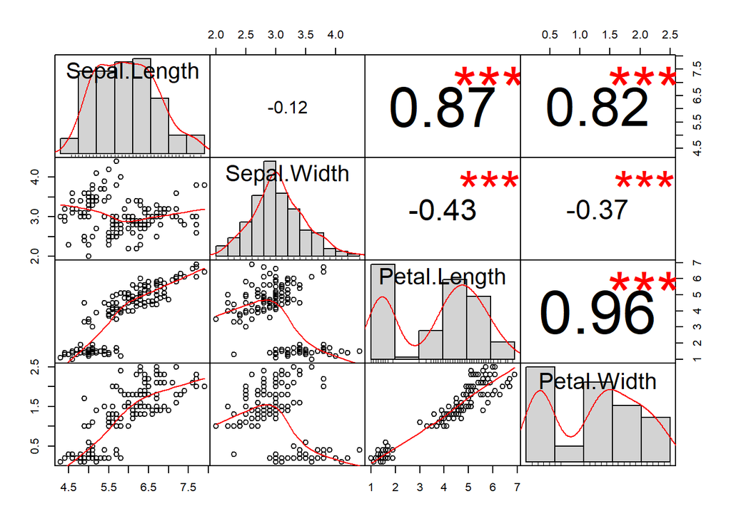

```r
write.csv(base_correlation_table,
          file = paste0(TABLEDIR,"week5_iris_correlations.csv"),
          row.names = FALSE)

# fancy version with histograms and scatter plots
# from PerformanceAnalytics library
iris_measurements %>%
  select(-Species) %>% # again remove the Species field
  chart.Correlation(histogram=TRUE)
```

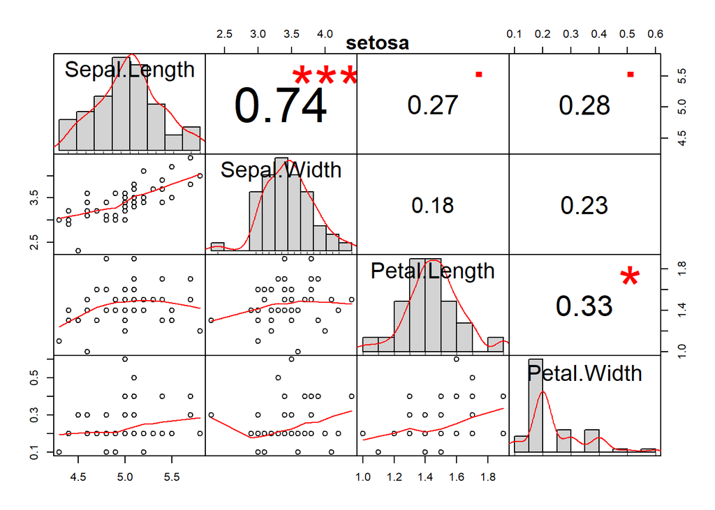

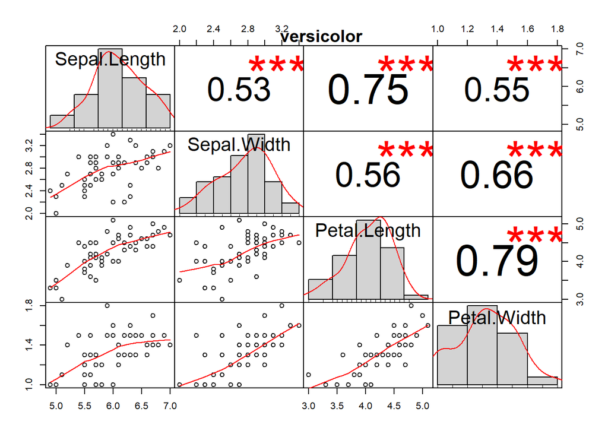

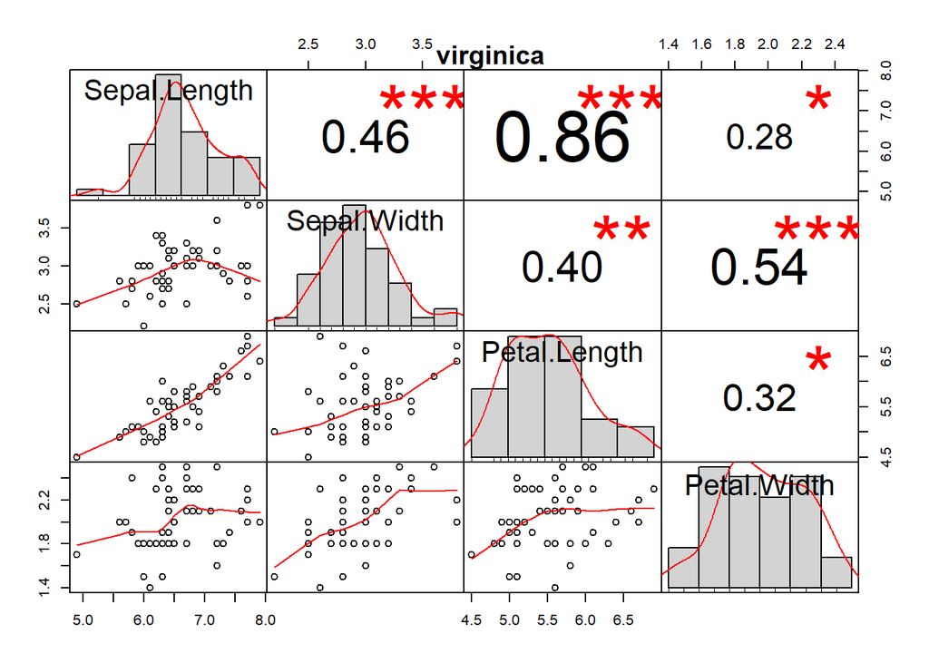

```r
# re-run for each species separately
for (species in unique(iris_measurements$Species)) { # on each iteration a different species is run
  iris_measurements %>%
    filter(Species == species) %>% # filter to just that species' data
    select(-Species) %>%
    chart.Correlation(histogram = TRUE)
    title(species) # add title to the graphs
}
```

```r
# repeat last call to also save it to file
for (species in unique(iris_measurements$Species)) {
  png(filename = paste0(GRAPHDIR, "week5_", species, "_corrplot.png"))
  iris_measurements %>%
    filter(Species == species) %>%
    select(-Species) %>%
    chart.Correlation(histogram = TRUE)
  title(species) # add title to the graphs
  dev.off()
}
```

### Version 1a - SPL data

#### Contingency Tables

```r
# Let's start with our checkouts table AND remind ourselves of what that looks like
head(checkouts)
```

```
##         Date Year WeekOfYear     Month DayOfWeek Hour   Age Collection
## 1 2019-05-30 2019         22       May  Thursday   14 Adult Nonfiction
## 2 2018-12-23 2018         51  December    Sunday   14 Adult Nonfiction
## 3 2019-10-02 2019         40   October Wednesday   16 Adult Nonfiction
## 4 2019-10-11 2019         41   October    Friday   17 Adult Nonfiction
## 5 2018-11-03 2018         44  November  Saturday   10 Adult Nonfiction
## 6 2018-09-09 2018         36 September    Sunday   13 Adult Nonfiction
##   SubCollection
## 1     Biography
## 2     Biography
## 3     Biography
## 4     Biography
## 5     Biography
## 6     Biography
```

```r
# first contingency table - Collection vs Age
# step 1 - group data by Collection and Age
collection_age <- checkouts %>%
                  group_by(Collection, Age) %>%
                  summarize(Checkouts = n()) # count the rows because each row is ONE checkout
# step 2 - make the table "wide" by showing Ages as column names
collection_v_age <- collection_age %>%
                    pivot_wider(names_from = Age,
                                values_from = Checkouts,
                                values_fill = 0)

# step 3 - view results
collection_v_age
```

```
## # A tibble: 2 x 3
## # Groups:   Collection [2]
##   Collection Adult Juvenile
##   <chr>      <int>    <int>
## 1 Fiction    46125    68481
## 2 Nonfiction 50532    13803
```

```r
# step 4 - export to csv
write.csv(collection_v_age,
          file = paste0(TABLEDIR, "week5_SPL_collectionVage_contingency.csv"),
          row.names = FALSE)

# second contingency table - Month vs Age
# group by both values and then use pivot_wider to move one to the column labels
month_vs_age <- checkouts %>%
                group_by(Month, Age) %>%
                summarize(Checkouts = n()) %>% # count the data as each row is ONE checkout
                pivot_wider(names_from = Age,
                            values_from = Checkouts,
                            values_fill = 0) # if we don't have data assume zero checkouts
month_vs_age # this is data for ALL years 2018 - 2020
```

```
## # A tibble: 12 x 3
## # Groups:   Month [12]
##    Month     Adult Juvenile
##    <ord>     <int>    <int>
##  1 January   11065     9363
##  2 February   9737     8397
##  3 March      9170     8069
##  4 April      7012     5808
##  5 May        6829     5528
##  6 June       7083     6062
##  7 July       7332     6563
##  8 August     7360     6385
##  9 September  7420     6482
## 10 October    8077     6903
## 11 November   7694     6809
## 12 December   7878     5915
```

```r
write.csv(month_vs_age,
          file = paste0(TABLEDIR, "week5_SPL_monthVage_contingency.csv"),
          row.names = FALSE)
```

#### Produce & export one regression table with SPL data

```r
# Let's start with our checkouts table AND remind ourselves of what that looks like
head(checkouts)
```

```
##         Date Year WeekOfYear     Month DayOfWeek Hour   Age Collection
## 1 2019-05-30 2019         22       May  Thursday   14 Adult Nonfiction
## 2 2018-12-23 2018         51  December    Sunday   14 Adult Nonfiction
## 3 2019-10-02 2019         40   October Wednesday   16 Adult Nonfiction
## 4 2019-10-11 2019         41   October    Friday   17 Adult Nonfiction
## 5 2018-11-03 2018         44  November  Saturday   10 Adult Nonfiction
## 6 2018-09-09 2018         36 September    Sunday   13 Adult Nonfiction
##   SubCollection
## 1     Biography
## 2     Biography
## 3     Biography
## 4     Biography
## 5     Biography
## 6     Biography
```

```r
# We need to build a derivative table that includes two different numerical fields
# I'm going to make several counts on the WeekOfYear and Year fields so that we can try
# some of the correlation plots from above too.
# What this means is that in each case, I'll be using WeekOfYear and Year to group the data
# And then count from there.

# Age
age <- checkouts %>%
  group_by(Year, WeekOfYear, Age) %>%
  summarize(Checkouts = n()) %>%
  pivot_wider(names_from = Age,
              values_from = Checkouts,
              values_fill = 0)
head(age)
```

```
## # A tibble: 6 x 4
## # Groups:   Year, WeekOfYear [6]
##    Year WeekOfYear Adult Juvenile
##   <int> <chr>      <int>    <int>
## 1  2018 01           926      808
## 2  2018 02           851      719
## 3  2018 03           713      673
## 4  2018 04           847      757
## 5  2018 05           883      747
## 6  2018 06           818      702
```

```r
# Collection
collection <- checkouts %>%
  group_by(Year, WeekOfYear, Collection) %>%
  summarize(Checkouts = n()) %>%
  pivot_wider(names_from = Collection,
              values_from = Checkouts,
              values_fill = 0)
head(collection)
```

```
## # A tibble: 6 x 4
## # Groups:   Year, WeekOfYear [6]
##    Year WeekOfYear Fiction Nonfiction
##   <int> <chr>        <int>      <int>
## 1  2018 01            1093        641
## 2  2018 02             983        587
## 3  2018 03             885        501
## 4  2018 04            1010        594
## 5  2018 05            1023        607
## 6  2018 06             932        588
```

```r
# Time of Day
checkouts$Hour <- as.numeric(checkouts$Hour)
checkouts$DayPart <- ifelse(checkouts$Hour %in% c(0, 1,2,3,4,5), "early morning",
                     ifelse(checkouts$Hour %in% c(6, 7, 8, 9, 10, 11), "morning",
                     ifelse(checkouts$Hour %in% c(12, 13, 14, 15, 16, 17), "afternoon",
                            "night")))
checkouts %>% select(Hour, DayPart) %>% unique()
```

```
##       Hour   DayPart
## 1       14 afternoon
## 3       16 afternoon
## 4       17 afternoon
## 5       10   morning
## 6       13 afternoon
## 8       15 afternoon
## 15      18     night
## 19      11   morning
## 32      12 afternoon
## 53      19     night
## 60       9   morning
## 1544     8   morning
## 2714    20     night
## 11231   22     night
## 17455    7   morning
```

```r
daypart <- checkouts %>%
  group_by(Year, WeekOfYear, DayPart) %>%
  summarize(Checkouts = n()) %>%
  pivot_wider(names_from = DayPart,
              values_from = Checkouts,
              values_fill = 0)
head(daypart)
```

```
## # A tibble: 6 x 5
## # Groups:   Year, WeekOfYear [6]
##    Year WeekOfYear afternoon morning night
##   <int> <chr>          <int>   <int> <int>
## 1  2018 01              1407     223   104
## 2  2018 02              1217     243   110
## 3  2018 03              1082     216    88
## 4  2018 04              1239     236   129
## 5  2018 05              1250     247   133
## 6  2018 06              1156     244   120
```

```r
# now let's merge these together
checkouts_YearWeek <- merge(x = age,
                            y = collection,
                            by = c("Year", "WeekOfYear"),
                            all = TRUE) # keep data even if missing in one of x or y
checkouts_YearWeek <- merge(x = checkouts_YearWeek,
                            y = daypart,
                            by = c("Year", "WeekOfYear"),
                            all = TRUE)
# There might be NAs from the merges
sum(is.na(checkouts_YearWeek)) # 0 in my case
```

```
## [1] 0
```

```r
head(checkouts_YearWeek)
```

```
##   Year WeekOfYear Adult Juvenile Fiction Nonfiction afternoon morning night
## 1 2018         01   926      808    1093        641      1407     223   104
## 2 2018         02   851      719     983        587      1217     243   110
## 3 2018         03   713      673     885        501      1082     216    88
## 4 2018         04   847      757    1010        594      1239     236   129
## 5 2018         05   883      747    1023        607      1250     247   133
## 6 2018         06   818      702     932        588      1156     244   120
```

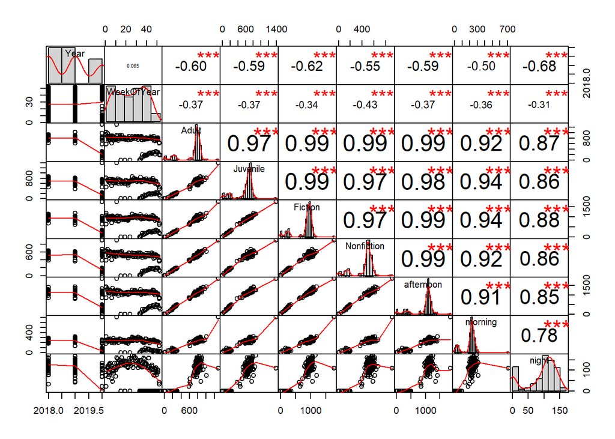

```r
# plot chart correlations
checkouts_YearWeek$WeekOfYear <- as.numeric(checkouts_YearWeek$WeekOfYear)
chart.Correlation(checkouts_YearWeek, histogram = TRUE)
```

```r
# Linear regression: predict number of juvenile checkouts based on adult checkouts
fit.adultCheckouts <- lm(Juvenile ~ Adult,
                         data = checkouts_YearWeek)
# Let's view the fit diagnostics and then pull some of them into a regression table
summary(fit.adultCheckouts)
```

```
##
## Call:
## lm(formula = Juvenile ~ Adult, data = checkouts_YearWeek)
##
## Residuals:
##      Min       1Q   Median       3Q      Max
## -164.474  -29.308    0.168   28.192  265.930
##
## Coefficients:
##              Estimate Std. Error t value            Pr(>|t|)
## (Intercept) -34.72856   14.44169  -2.405              0.0175 *
## Adult         0.90124    0.01953  46.144 <0.0000000000000002 ***
## ---
## Signif. codes:  0 '***' 0.001 '**' 0.01 '*' 0.05 '.' 0.1 ' ' 1
##
## Residual standard error: 57.89 on 137 degrees of freedom
## Multiple R-squared:  0.9395, Adjusted R-squared:  0.9391
## F-statistic:  2129 on 1 and 137 DF,  p-value: < 0.00000000000000022
```

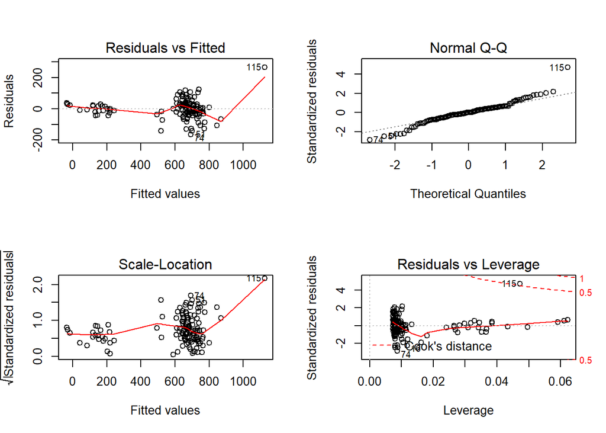

```r
par(mfrow=c(2,2))
plot(fit.adultCheckouts)
```

```r
# Table of regression information to inlcude:
#    Diagnostics of overall Fit (Multiple R-squared, Adjusted multiple R-squared, Fstatistic & p-value)
#    Coefficients & their fits (t-value & Pr(>|t|))
summary.fit.adultCheckouts <- summary(fit.adultCheckouts)
fstat.fit.adultCheckouts <- summary.fit.adultCheckouts$fstatistic
coefficients.fit.adultCheckouts <- data.frame(summary.fit.adultCheckouts$coefficients)
results.fit.adultCheckouts <- rbind(# build table one row at a time
                                    c("Overall Metrics", "Mult. R-squared", "Adj. R-squared", "F-statistic", "p-value"),
                                    c("", # no value
                                      round(summary.fit.adultCheckouts$r.squared, 3),
                                      round(summary.fit.adultCheckouts$adj.r.squared, 3),
                                      round(summary.fit.adultCheckouts$fstatistic[1], 3),
                                      round(pf(q = fstat.fit.adultCheckouts[1],
                                               df1 = fstat.fit.adultCheckouts[2],
                                               df2 = fstat.fit.adultCheckouts[3],
                                               lower.tail = FALSE), 4)),
                                    c("", "", "", "", ""), # add an empty row
                                    c("Variable", "Estimate", "t-value", "Pr(>|t|)", ""),
                                    c("(Intercept)",
                                      round(coefficients.fit.adultCheckouts$Estimate[1], 3),
                                      round(coefficients.fit.adultCheckouts$t.value[1], 3),
                                      round(coefficients.fit.adultCheckouts$Pr...t..[1], 4),
                                      ""),
                                    c("Adult",
                                      round(coefficients.fit.adultCheckouts$Estimate[2], 3),
                                      round(coefficients.fit.adultCheckouts$t.value[2], 3),
                                      round(coefficients.fit.adultCheckouts$Pr...t..[2], 4),
                                      ""))
colnames(results.fit.adultCheckouts) <- c("", "", "", "", "") # blank out column names
results.fit.adultCheckouts
```

```
##
## [1,] "Overall Metrics" "Mult. R-squared" "Adj. R-squared" "F-statistic"
## [2,] ""                "0.94"            "0.939"          "2129.299"
## [3,] ""                ""                ""               ""
## [4,] "Variable"        "Estimate"        "t-value"        "Pr(>|t|)"
## [5,] "(Intercept)"     "-34.729"         "-2.405"         "0.0175"
## [6,] "Adult"           "0.901"           "46.144"         "0"
##
## [1,] "p-value"
## [2,] "0"
## [3,] ""
## [4,] ""
## [5,] ""
## [6,] ""
```

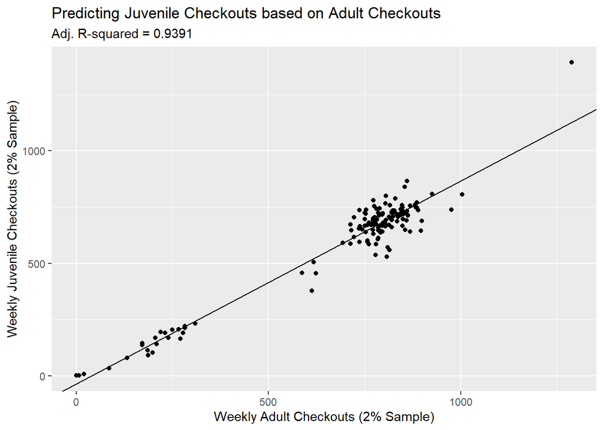

```r
write.csv(results.fit.adultCheckouts,
          file = paste0(TABLEDIR, "week5_results_fit_adultCheckouts.csv"),
          row.names = FALSE)

# graph results
(ggplot(checkouts_YearWeek)
  + aes(x = Adult, y = Juvenile)
  + geom_point()
  + geom_abline(intercept = fit.adultCheckouts$coefficients['(Intercept)'],
                slope = fit.adultCheckouts$coefficients['Adult'])
  + ggtitle("Predicting Juvenile Checkouts based on Adult Checkouts",
            subtitle = paste0("Adj. R-squared = ", round(summary.fit.adultCheckouts$adj.r.squared, 4)))
  + scale_y_continuous("Weekly Juvenile Checkouts (2% Sample)")
  + scale_x_continuous("Weekly Adult Checkouts (2% Sample)")
  )
```

```r
ggsave(filename = paste0(GRAPHDIR,"week5_weeklyCheckouts_prediction.png"),
       width = PLOT_WIDTH,
       height = PLOT_HEIGHT,
       units = PLOT_UNITS)
```

## Week 6

### Assignment (summarized)

Extend last week’s regression model with a categorical variable.

1. Choose a categorical variable and add it to the regression as a dummy variable. Create a scatter plot with multiple regression lines (one for each categorical value).
2. Subset the data by the categorical variable and run independent regressions. Plot these as well.

### Part 1 - Regression with a categorical variable

Last week, we attempted to predict Juvenile weekly checkouts based on weekly Adult behavior. This week, let’s add a categorical variable to that analysis. In particular, we are going to add coding for the time of year (holiday - summer and winter vs not).

```r
checkouts_Age <- checkouts %>%
                 group_by(Year, WeekOfYear, Age) %>%
                 summarize(Checkouts = n()) %>%
                 pivot_wider(names_from = Age,
                             values_from = Checkouts,
                             values_fill = 0)
# add in holiday categories
checkouts_Age$Holiday <- "No" # default
checkouts_Age$Holiday[as.numeric(checkouts_Age$WeekOfYear) %in% c(1, 52, 53)] <- "Winter" # last week-ish Dec + first week Jan
checkouts_Age$Holiday[as.numeric(checkouts_Age$WeekOfYear) %in% c(25:34)] <- "Summer" # roughly mid-June to late-Aug
head(checkouts_Age)
```

```
## # A tibble: 6 x 5
## # Groups:   Year, WeekOfYear [6]
##    Year WeekOfYear Adult Juvenile Holiday
##   <int> <chr>      <int>    <int> <chr>
## 1  2018 01           926      808 Winter
## 2  2018 02           851      719 No
## 3  2018 03           713      673 No
## 4  2018 04           847      757 No
## 5  2018 05           883      747 No
## 6  2018 06           818      702 No
```

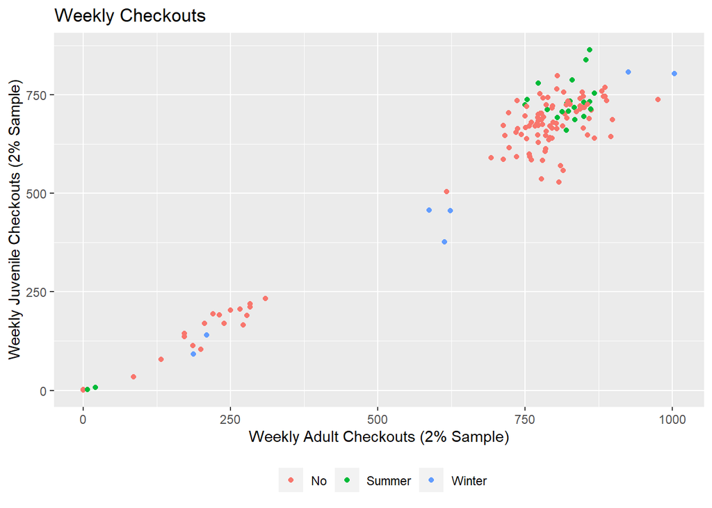

```r
# drop outlier with highest value for both
checkouts_Age <- checkouts_Age[checkouts_Age$Adult < 1200,]

# plot to see the separation
(ggplot(checkouts_Age)
  + aes(x = Adult,
        y = Juvenile,
        color = Holiday)
  + geom_point()
  + ggtitle("Weekly Checkouts")
  + scale_x_continuous("Weekly Adult Checkouts (2% Sample)")
  + scale_y_continuous("Weekly Juvenile Checkouts (2% Sample)")
  + scale_color_discrete("")
  + theme(legend.position = "bottom")
  )
```

```r
fit.adultCheckouts.Holiday <- lm(Juvenile ~ Adult + factor(Holiday),
                                 data = checkouts_Age)
# review results
summary(fit.adultCheckouts.Holiday)
```

```
##
## Call:
## lm(formula = Juvenile ~ Adult + factor(Holiday), data = checkouts_Age)
##
## Residuals:
##      Min       1Q   Median       3Q      Max
## -156.255  -24.615   -2.121   30.021  116.364
##
## Coefficients:
##                       Estimate Std. Error t value            Pr(>|t|)
## (Intercept)           -20.1972    13.0036  -1.553              0.1227
## Adult                   0.8731     0.0176  49.606 <0.0000000000000002 ***
## factor(Holiday)Summer  34.4583    11.8948   2.897              0.0044 **
## factor(Holiday)Winter -49.1495    19.8192  -2.480              0.0144 *
## ---
## Signif. codes:  0 '***' 0.001 '**' 0.01 '*' 0.05 '.' 0.1 ' ' 1
##
## Residual standard error: 50.66 on 134 degrees of freedom
## Multiple R-squared:  0.9505, Adjusted R-squared:  0.9494
## F-statistic: 858.2 on 3 and 134 DF,  p-value: < 0.00000000000000022
```

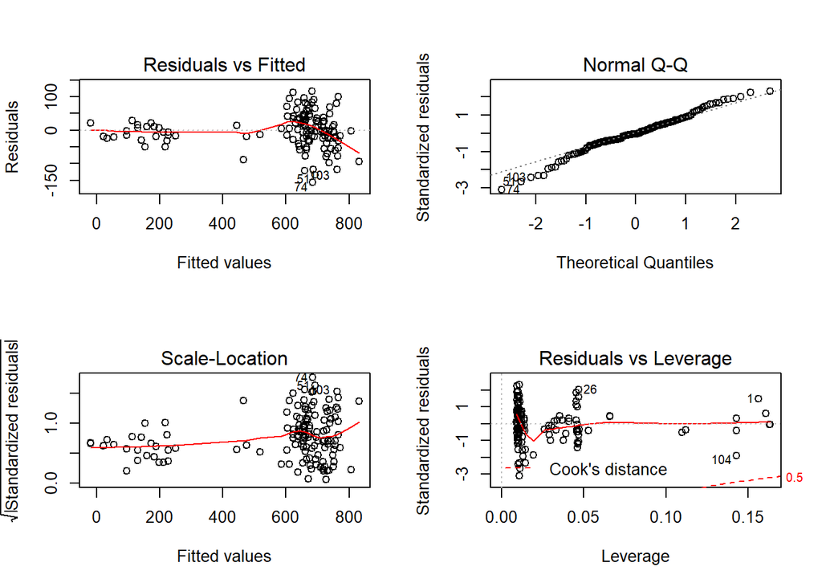

```r
par(mfrow=c(2,2))
plot(fit.adultCheckouts.Holiday)
```

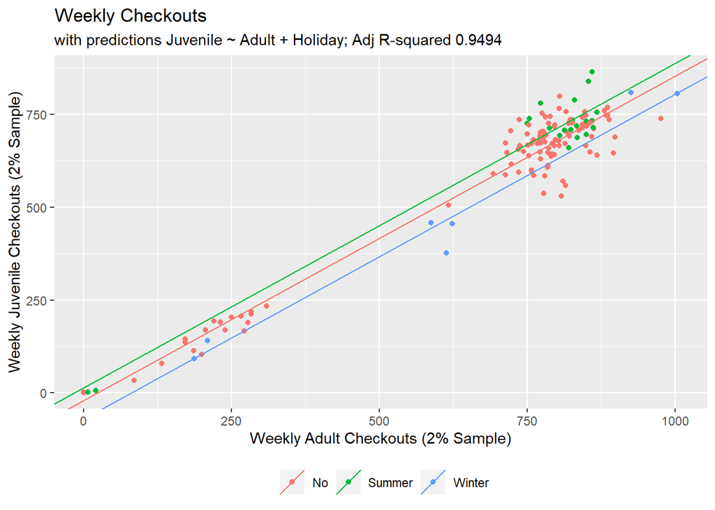

```r
# store slopes and intercepts for plotting
lines.fit.adultCheckouts.Holiday <- data.frame(
  slopes = rep(fit.adultCheckouts.Holiday$coefficients['Adult'], 3),
  intercepts = c(fit.adultCheckouts.Holiday$coefficients['(Intercept)'], # No holiday
                 fit.adultCheckouts.Holiday$coefficients['(Intercept)'] +
                   fit.adultCheckouts.Holiday$coefficients['factor(Holiday)Winter'], # Winter
                 fit.adultCheckouts.Holiday$coefficients['(Intercept)'] +
                   fit.adultCheckouts.Holiday$coefficients['factor(Holiday)Summer']), # Summer
  groups = c("No", "Winter", "Summer"))

# plot the lines
(ggplot(checkouts_Age)
  + aes(x = Adult,
        y = Juvenile,
        color = Holiday)
  + geom_point()
  + geom_abline(data = lines.fit.adultCheckouts.Holiday,
                aes(slope = slopes,
                    intercept = intercepts,
                    color = groups))
  + ggtitle("Weekly Checkouts",
            subtitle = paste0("with predictions Juvenile ~ Adult + Holiday; Adj R-squared ",
                              round(summary(fit.adultCheckouts.Holiday)$adj.r.squared, 4)))
  + scale_x_continuous("Weekly Adult Checkouts (2% Sample)")
  + scale_y_continuous("Weekly Juvenile Checkouts (2% Sample)")
  + scale_color_discrete("")
  + theme(legend.position = "bottom")
  )
```

```r
ggsave(filename = paste0(GRAPHDIR,"week6_weeklyCheckouts_prediction_withholiday.png"),
       width = PLOT_WIDTH,
       height = PLOT_HEIGHT,
       units = PLOT_UNITS)
```

### Part 2 - Regression with individual subsets

Now let’s compare our SINGLE regression with dummy variables to multiple regressions (one for each subset of data with a particular Holiday value). We will show the results via a graph and a table of the R-squared values.

```r
# recreate last week's model to pull the r-squared values
fit.adultCheckouts <- lm(Juvenile ~ Adult,
                         data = checkouts_Age)
results.rsquared <- data.frame("Equation" = "Juvenile ~ Adult",
                               "Group" = "All",
                               "Multiple R-squared" = round(summary(fit.adultCheckouts)$r.squared, 4),
                               "Adjusted R-squared" = round(summary(fit.adultCheckouts)$adj.r.squared, 4))
# sequentially add on each new set of results, first from the part 1 regression
results.rsquared <- rbind(results.rsquared,
                          data.frame(
                            "Equation" = "Juvenile ~ Adult + Holiday",
                            "Group" = "All",
                            "Multiple R-squared" = round(summary(fit.adultCheckouts.Holiday)$r.squared, 4),
                            "Adjusted R-squared" = round(summary(fit.adultCheckouts.Holiday)$adj.r.squared, 4)))

# view thus far
results.rsquared
```

```
##                     Equation Group Multiple.R.squared Adjusted.R.squared
## 1           Juvenile ~ Adult   All             0.9446             0.9442
## 2 Juvenile ~ Adult + Holiday   All             0.9505             0.9494
```

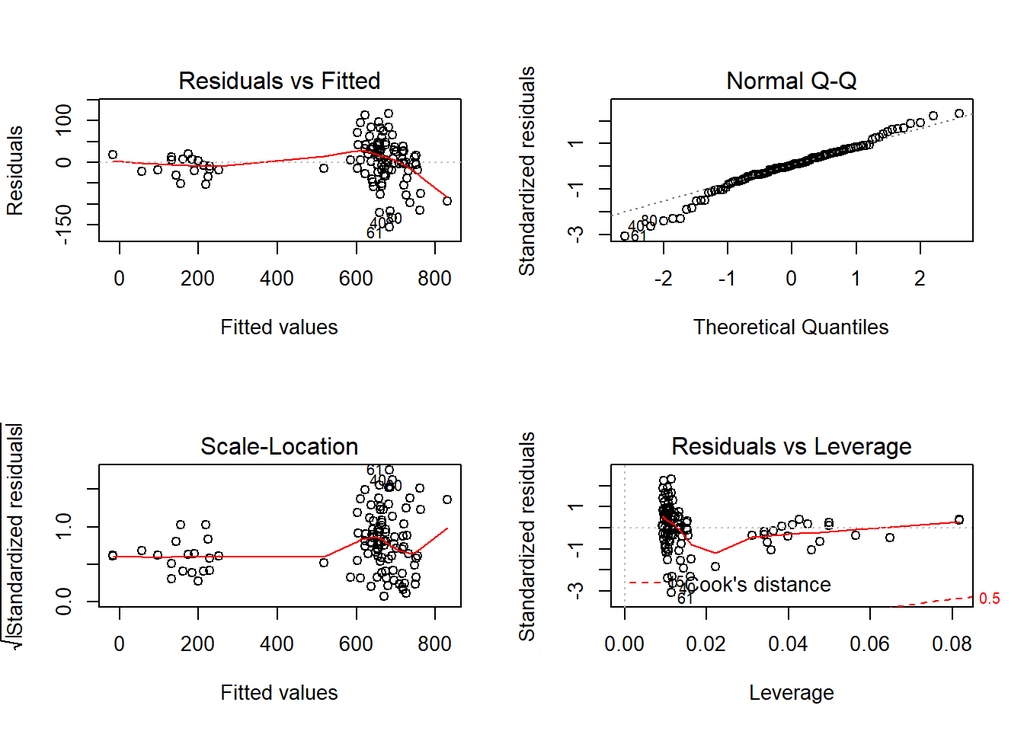

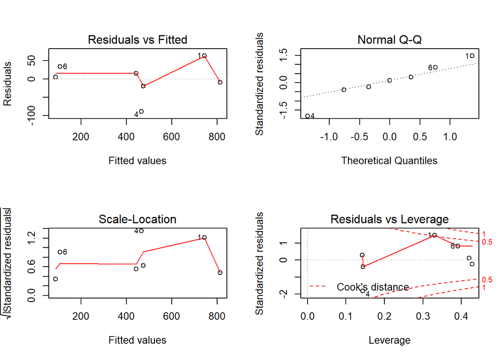

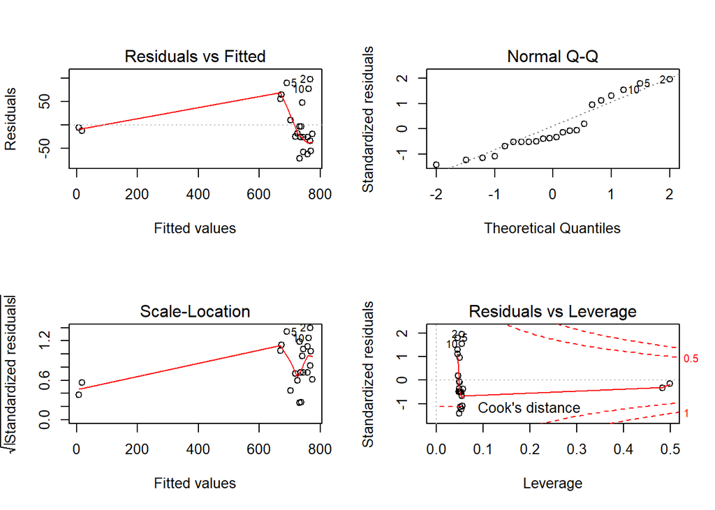

```r
# make some updates to the slope/intercept data.frame for plotting
lines.fit.adultCheckouts.Holiday$subsets <- "Dummy Variable" # add new line to differentiate all vs subset

# Now subset the data and run a regression for each Holiday set
for (holidaySet in c("No", "Winter", "Summer")) {
  # run model
  fit.adultCheckouts.subset <- lm(Juvenile ~ Adult,
                                  data = checkouts_Age[checkouts_Age$Holiday == holidaySet,])
  summary(fit.adultCheckouts.subset)
  par(mfrow = c(2,2))
  plot(fit.adultCheckouts.subset)

  # save R-squareds
  results.rsquared <- rbind(results.rsquared,
                          data.frame(
                            "Equation" = "Juvenile ~ Adult",
                            "Group" = holidaySet,
                            "Multiple R-squared" = round(summary(fit.adultCheckouts.subset)$r.squared, 4),
                            "Adjusted R-squared" = round(summary(fit.adultCheckouts.subset)$adj.r.squared, 4)))

  # save slope & intercept for plotting
  lines.fit.adultCheckouts.Holiday <- rbind(lines.fit.adultCheckouts.Holiday,
      data.frame(slopes = fit.adultCheckouts.subset$coefficients['Adult'],
                 intercepts = fit.adultCheckouts.subset$coefficients['(Intercept)'],
                 groups = holidaySet,
                 subsets = "Subset"))
}
```